# HW 10 - advMCMC

Eunchong Kang

04/05/2022

# MCMC extension of HW 6

The probability of $Y$ is $P(Y=y \, | \pi, \lambda) = \pi I(y=0) +(1-\pi)\frac{e^{-\lambda}\lambda^y}{y!}$ \

Thus, the posterior distribution is below.

$$\begin{align}
\log f(\pi,\lambda | \boldsymbol{y}) &\propto \log f(\boldsymbol{y} | \pi, \lambda)f(\pi,\lambda)\\
&= n_0 \log (\pi + (1-\pi)e^{-\lambda}) + \sum_{k=1}^{6} n_k \log (1-\pi)\frac{e^{-\lambda}\lambda^k}{k!} + \log f(\pi) + \log f(\lambda) \\
\end{align}$$

where $\pi \sim U(0,1)$ and $\lambda \sim Gamma(2,2)$.

Metropolis-within-Gibbs method will be used, but every step in the Gibbs cycle will be replaced by a Metropolis step using a random walk.

For $\pi$, it was reparameterized into $u = \log \frac{\pi}{1-\pi}$ and $|J|=\frac{1}{p(1-p)}$. Therefore, its proposal was $u^* = u^{(t)} + \epsilon_{\pi}$, where $\epsilon_{\pi} \sim N(0,0.12^2)$.  
For $\lambda$, it was not reparameterized, but when $x^*$ from $x^* = x^{(t)} + \epsilon_{\lambda}$ was non-positive, the proposal was not accepted. The distribution was $\epsilon_{\lambda} \sim N(0, 0.09^2)$ to achieve the acceptance rate of around 0.44.

The chain was created using $M = 20000$, random seed (1), starting values ($\pi^{(0)} = 0.3$, $\lambda = 3$), and burn-in period (2000 iterations).  
For the result, trace plots, autocorrelation, and acceptance rates were used for chain diagnostics. And then, the posterior means for $\pi$ and $\lambda$ were calculated from the mean of the chain.

## 1. Creating Helper Functions

1. ‘lplambda’ is the function of Log-prior for $\lambda$
2. ‘lppi’ is the function of Log-prior for $\pi$
3. ‘logit’ is the logit function
4. ‘inv.logit’ is the Inverse logit function
5. ‘r.walk_u’ is the Random walk function for $\pi$
6. ‘r.walk_lambda’ is the Random walk function for $\lambda$
7. ‘ll’ is the Log-likelihood function
8. ‘R’ is the MH ratio function

```r
### HELPER FUNCTIONS
# 1. log prior for lambda
lplambda <- function(lambda){
        lplambda <- dgamma(lambda, shape=2, scale=2, log=TRUE)

        return(lplambda)
}

# 2. log prior for pi
# This is not necessary b/c its value is always 1
lppi <- function(pi){
        lppi <- dunif(pi, min=0, max=1, log=TRUE)

        return(lppi)
}

# Change of variable for pi
# 3. logit function
logit <- function(pi){
        u <- log(pi/(1-pi))

        return(u)
}

# 4. inverse logit function
inv.logit <- function(u){
        pi <- exp(u)/(1+exp(u))

        return(pi)
}

# Functions of producing a random walk.
# 5. N(0, 0.12^2) for u (and pi)
r.walk_u <- function(){
        r.walk <- rnorm(1, mean=0, sd=0.12)

        return(r.walk)
}
# 6. normal(0, 0.09^2) for lambda
r.walk_lambda <- function(){
        r.walk <- rnorm(1, mean=0, sd=0.09)

        return(r.walk)
}


# 7. Log-likelihood
ll <- function(y, ny, x){
  pi = x[1]
  lambda = x[2]

  # when y = 0
  y0 <- ny[which(y==0)]*log(pi + (1-pi)*exp(-lambda))

  # when y > 0 (y greater then 0)
  ygt0 <- sum(ny[which(y!=0)] * log((1-pi)*dpois(y[which(y!=0)], lambda=lambda)))

  # log-Jacobian for pi and u
  log_jacob <- -log(pi*(1-pi))

  # log-likelihood
  ll <- y0 + ygt0 + lplambda(lambda) + lppi(pi) + log_jacob

  return(ll)
}


# 8. MH ratio
R <- function(y, ny, x, xt){
        logR <- ll(y,ny,x) - ll(y,ny,xt)
        R <- exp(logR)

        return(R)
}
```

## 2. Setting up

```r
# set the seed
set.seed(1)

# data
y <- 0:6
ny <- c(3062, 587, 284, 103, 33, 4, 2)

# Set chain length and Burn.in
M <- 20000
burn.in <- 2000

# initialize the chain vector (alpha, lambda)
x.rw.chain <- matrix(0, M + burn.in, 2)
colnames(x.rw.chain) <- c("pi","lambda")

# Initialize chain with specified initial values
# alpha, lambda
x.rw.chain[1,] <- c(0.3, 3)

# Creating an empty vector for acceptance rate
accept <- rep(0,2)
```

## 3. Sampling

```r
# now start chain
for(i in 1:(M - 1 + burn.in)) {
        # set the value at current iteration of the chain to variable xt
        xt <- x.rw.chain[i, ]

        ### loop for pi and lambda

        ## Step 1: pi
        # set proposal equal to previous
        x <- xt

        # change of variable
        u <- logit(x[1])

        # Update
        u <- u + r.walk_u()

        # Transform back to pi
        x[1] <- inv.logit(u)

        # Calculate MH ratio
        r <- min(R(y, ny, x, xt), 1)

        # Generate draw from bernoulli(r)
        keep <- rbinom(1,1,r)

        # if keep = 1, then set next iteration equal to then proposal
        if (keep == 1) {
                # update into the chain
                x.rw.chain[i + 1, ] <- x

                # reset xt
                xt <- x

                # update number of acceaptance
                accept[1] <- accept[1] + 1
        } else{
                # otherwise, carry over value from the current iteration
                x.rw.chain[i + 1, ] <- xt
        }
        ## The end of Step 1 (pi)


        ## Step 2: lambda
        # set proposal equal to previous
        x <- xt

        # Candidate
        proposed <- x[2] + r.walk_lambda()

        # If proposed x is non-positive, then use xt.
        if (proposed <= 0){
                r <- 0
        } else {
                x[2] <- proposed

                # Calculate MH ratio
                r <- min(R(y, ny, x, xt), 1)
        }

        # Generate draw from bernoulli(r)
        keep <- rbinom(1,1,r)

        # if keep = 1, then set next iteration equal to then proposal
        if (keep == 1) {
                x.rw.chain[i + 1, ] <- x

                # reset xt
                xt <- x

                # update number of acceaptance
                accept[2] <- accept[2] + 1
        } else {
                # otherwise, carry over value from the current iteration
                x.rw.chain[i + 1, ] <- xt
        }
        ## The end of Step 1 (lambda)
        ### The end of loop for pi and lambda
        # now, one sample is created.
}

# Deleting burn.in samples.
x.rw.chain <- x.rw.chain[-c(1:burn.in),]
```

```r
# print posterior means and diagnostic plots.  Comment on convergence

# Acceptance rates
accept/M
```

```
## [1] 0.44675 0.42395
```

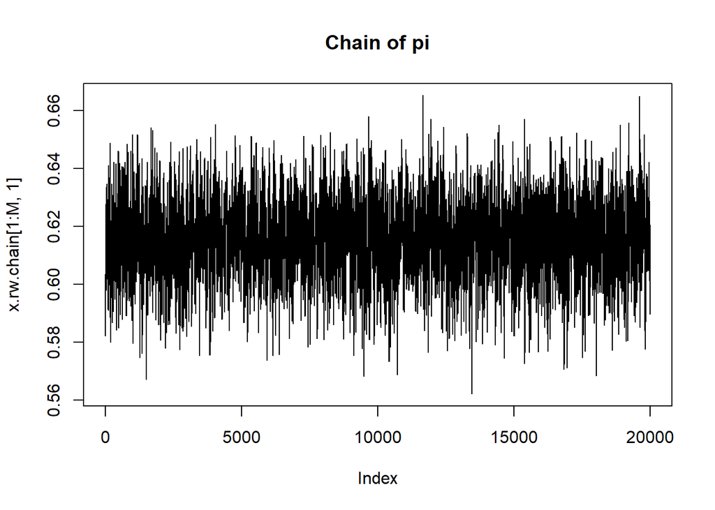

```r
# Plot of samples
plot(x.rw.chain[1:M,1], type="l", main="Chain of pi")
```

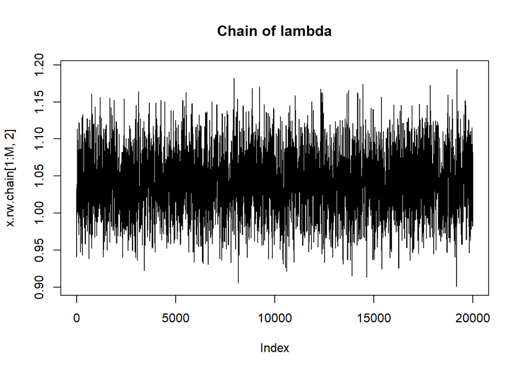

```r
plot(x.rw.chain[1:M,2], type="l", main="Chain of lambda")
```

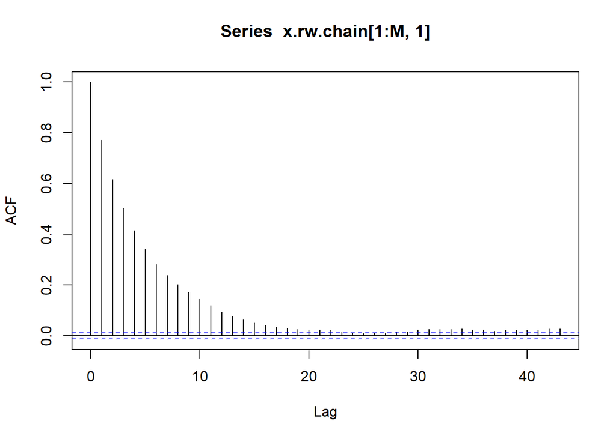

```r
# Autocorrelation plots
acf(x.rw.chain[1:M,1])
```

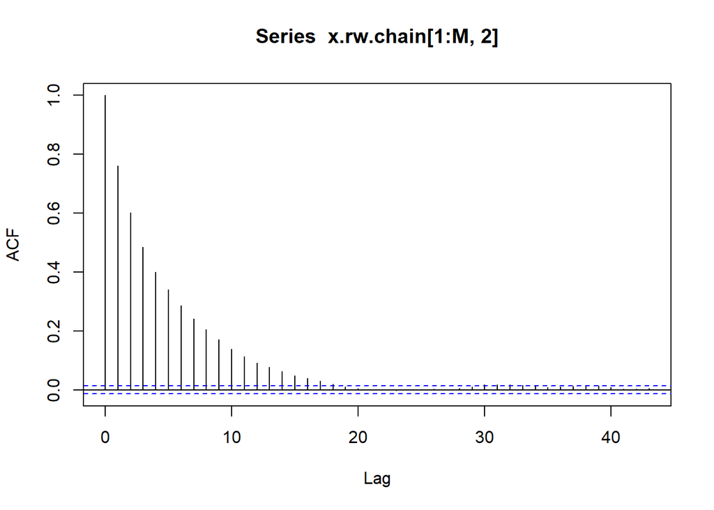

```r
acf(x.rw.chain[1:M,2])
```

```r
# Mean of posterior means for pi
mean(x.rw.chain[1:M,1])
```

```
## [1] 0.6154488
```

```r
# Mean of posterior means for lambda
mean(x.rw.chain[1:M,2])
```

```
## [1] 1.040472
```